# Praca domowa 2

Michał Cebula

2023-03-20

## Wstęp

Celem drugiej pracy domowej było sprawdzenie znajomości pakietu *ggplot2* oraz tworzenia poprawnych wizualizacji. W ramach pracy domowej należało przygotować, na podstawie wizualizacji dostępnej w prasie, telewizji lub internecie, i opublikowanej w ciągu ostatnich **2 tygodni**, poprawioną wizualizację utworzoną z wykorzystaniem biblioteki *ggplot2*, uwzględniając poznane na wykładzie dobre praktyki prezentacji danych.

## Rozpatrywana wizualizacja

Podstawą pracy była wizualizacja statystyk deklaracji CEEB (*Centralna Ewidencja Emisyjności Budynków*) opublikowanych przez GUNB (*Główny Urząd Nadzoru Budowlanego*) dnia 17 marca 2023r. i przedstawiająca na diagramie kołowym strukturę procentową zadeklarowanych źródeł ciepła ze względu na ich rodzaj.

Jak wiadomo diagramy kołowe ze względu na trudności w identyfikacji kątów przez człowieka nie są najlepszą metodą prezentacji danych. Ponadto przedstawiony wykres został utworzony w formie 3D, co dodatkowo utrudnia jego odczytywanie, zwłaszcza, że odcinki kołowe zostały dodatkowo od siebie oddzielone. Wykres pokazany w tej formie, pomimo efektownej prezentacji, jest w zasadzie interpretowany wyłącznie poprzez opisujące go adnotacje.

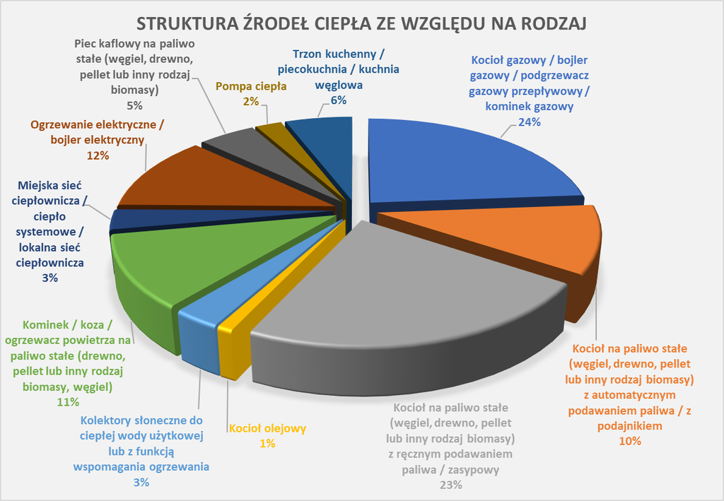

Wykres struktury procentowej zadeklorowanych źródeł ciepła w deklaracjach CEEB ze względu na ich rodzaj opublikowany przez GUNB dnia 17 marca 2023r. *Źródło: https://www.gunb.gov.pl/strona/statystyki*

## Przygotowanie danych

Dane dotyczące liczby zadeklarowanych źródeł ciepła w deklaracjach CEEB ze względu na ich rodzaj opublikowane przez GUNB dnia 17 marca 2023r. (*źródło: https://www.gunb.gov.pl/strona/statystyki*), po wprowadzeniu do ramki danych, prezentują się następująco:

```r
rodzaj_zrodla <- c(
  "Kocioł gazowy / bojler gazowy / podgrzewacz gazowy przepływowy / kominek gazowy",
  "Kocioł na paliwo stałe (węgiel, drewno, pellet lub inny rodzaj biomasy) z automatycznym podawaniem paliwa / z podajnikiem",
  "Kocioł na paliwo stałe (węgiel, drewno, pellet lub inny rodzaj biomasy) z ręcznym podawaniem paliwa / zasypowy",
  "Kocioł olejowy",
  "Kolektory słoneczne do ciepłej wody użytkowej lub z funkcją wspomagania ogrzewania",
  "Kominek / koza / ogrzewacz powietrza na paliwo stałe (drewno, pellet lub inny rodzaj biomasy, węgiel)",
  "Miejska sieć ciepłownicza / ciepło systemowe / lokalna sieć ciepłownicza",
  "Ogrzewanie elektryczne / bojler elektryczny",
  "Piec kaflowy na paliwo stałe (węgiel, drewno, pellet lub inny rodzaj biomasy)",
  "Pompa ciepła",
  "Trzon kuchenny / piecokuchnia / kuchnia węglowa"
) |> as.factor()

ilosc_deklaracji <- c(
  3295856L,
  1462355L,
  3142396L,
  136975L,
  412947L,
  1546958L,
  429881L,
  1633502L,
  676777L,
  314103L,
  807844L
)

zrodla_ciepla <- tibble(rodzaj_zrodla, ilosc_deklaracji) |>
  mutate(udzial_zrodla = ilosc_deklaracji / sum(ilosc_deklaracji),
         rodzaj_zrodla = fct_reorder(rodzaj_zrodla, udzial_zrodla))

knitr::kable(zrodla_ciepla)
```

| rodzaj_zrodla | ilosc_deklaracji | udzial_zrodla |
| --- | --- | --- |
| Kocioł gazowy / bojler gazowy / podgrzewacz gazowy przepływowy / kominek gazowy | 3295856 | 0.2378032 |
| Kocioł na paliwo stałe (węgiel, drewno, pellet lub inny rodzaj biomasy) z automatycznym podawaniem paliwa / z podajnikiem | 1462355 | 0.1055121 |
| Kocioł na paliwo stałe (węgiel, drewno, pellet lub inny rodzaj biomasy) z ręcznym podawaniem paliwa / zasypowy | 3142396 | 0.2267307 |
| Kocioł olejowy | 136975 | 0.0098830 |
| Kolektory słoneczne do ciepłej wody użytkowej lub z funkcją wspomagania ogrzewania | 412947 | 0.0297950 |
| Kominek / koza / ogrzewacz powietrza na paliwo stałe (drewno, pellet lub inny rodzaj biomasy, węgiel) | 1546958 | 0.1116164 |
| Miejska sieć ciepłownicza / ciepło systemowe / lokalna sieć ciepłownicza | 429881 | 0.0310169 |
| Ogrzewanie elektryczne / bojler elektryczny | 1633502 | 0.1178607 |
| Piec kaflowy na paliwo stałe (węgiel, drewno, pellet lub inny rodzaj biomasy) | 676777 | 0.0488309 |
| Pompa ciepła | 314103 | 0.0226632 |
| Trzon kuchenny / piecokuchnia / kuchnia węglowa | 807844 | 0.0582877 |

## Poprawiona wizualizacja

Przygotowana w ramach zadania wizualizacja przedstawia dane na klasycznym wykresie słupkowych przedstawionym poziomo ze względu na długości adnotacji przy osi opisującej słupki. Wykres w tej postaci pozwala na szybsze dostrzeżenie proporcji między udziałami dla poszczególnych kategorii, a dodatkowe uszeregowanie danych malejąco według udziału procentowego pozwala zauważyć nawet drobne różnice pomiędzy bliskimi sobie wartościami. Dane zaprezentowane w tej formie przekazują dodatkową informację w sposób graficzny, w przeciwieństwie do pierwotnego wykresu, w którym informacja praktycznie wyłącznie przekazywana była przez dane liczbowe obecne w adnotacjach naokoło wykresu.

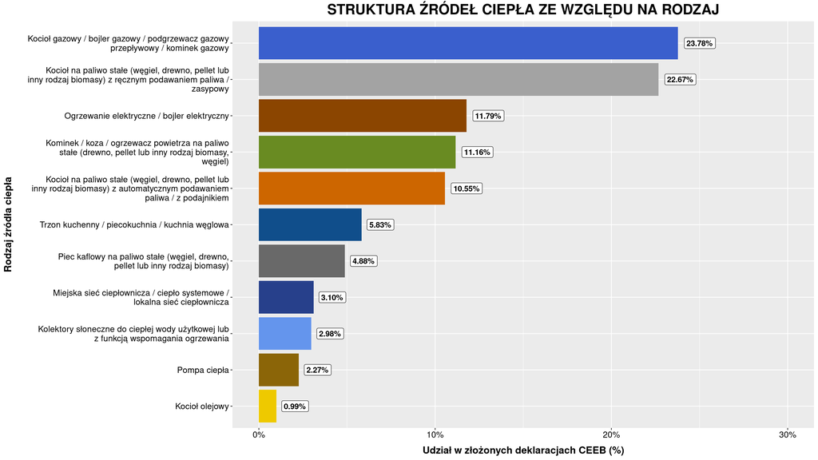

```r
custom_palette <- c(
  "gold2",
  "darkgoldenrod4",
  "cornflowerblue",
  "royalblue4",
  "dimgrey",
  "dodgerblue4",
  "darkorange3",
  "olivedrab4",
  "darkorange4",
  "grey64",
  "royalblue3"
)

zrodla_ciepla |>
  ggplot() +
    geom_col(aes(x = rodzaj_zrodla,
                 y = udzial_zrodla,
                 fill = rodzaj_zrodla)) +
    geom_label(aes(x = rodzaj_zrodla,
                   y = udzial_zrodla,
                   label = label_percent(accuracy = .01)(udzial_zrodla)),
               colour = "black",
               fontface = "bold",
               position = position_dodge(0.9),
               show.legend = FALSE,
               hjust = -0.2) +
    scale_x_discrete(labels = \(x) str_wrap(x, width = 50)) +
    scale_y_continuous(labels = label_percent(),
                       limits = c(0, 0.3)) +
    scale_fill_manual(values = custom_palette, guide = "none") +
    labs(title = "STRUKTURA ŹRÓDEŁ CIEPŁA ZE WZGLĘDU NA RODZAJ",
         x = "Rodzaj źródła ciepła",
         y = "Udział w złożonych deklaracjach CEEB (%)") +
    theme(plot.title = element_text(size = 20, face = "bold",  hjust = 0.5),
          axis.title = element_text(size = 14, color = "black", face = "bold"),
          axis.title.x = element_text(margin = margin(t = 10)),
          axis.title.y = element_text(margin = margin(r = 20)),
          axis.text = element_text(size = 12, color = "black")) +
    coord_flip()
```

## Podsumowanie

Zaprezentowany przykład wskazuje na to, że pomimo powszechności wszelakich wykresów w prasie, telewizji lub internecie, wciąż dobre praktyki wizualizacji danych nie są wcale tak powszechne jakby się mogło wydawać. Nie mniej jednak, znajdowanie wizualizacji stawiających komunikatywność i rzetelność przekazu ponad efekt wizualny staje się coraz łatwiejsze.